# NYC Bike Service Sharing

[figure not shown]

Launched in May 2013 and available 24/7, Citi Bike, New York City's bike share system, boasts thousands of bikes and hundreds of stations, making it the largest in the USA with 143,000 members in 2018. There are available two types of services, the "Customers" with 24-hour or 3-day passes and "Subscribers" with annual subscriptions. Citi Bikes serves diverse needs, leisure, tourism, and even job commutes.

## 1. Business Process and Data Flow

[figure not shown]

## 2. Decision-Making

The main measure that guides the NYC Citi Bikes business is the number of users that the company has. The amount of users (subscribers or simple users) will dictate the revenues of the company, for that it is important to know about the tendencies and preferences of users to offer the best service and experience.

This report has as propose answer 3 main questions:

- **When is the peak use of NYC Citi Bikes services?**

To know the seasons/months with more demand can help the company to how could manage/adjust their resources like the  
 number of bikes available, or the number of people working in certain positions.

- **Who is the typical user of NYC Citi Bikes services?**

To Knows the profile of clients it is relevant to adjust the services to fidelize the actual clients, but at the same  
 time looking to bring new type of costumers. This could be involve advertisements more efficient, or has additional  
 services like insurances to the people fell more secure.

- **Which travel is most common between stations?**

Maintenance of the bikes should have special attention because accidents that happen for a lack of maintenance could bring  
 bad reputation for the company and extra expenses with insurances or medical assistance. For that reason know which travel  
 happen most it is important to have more resources (maintenance points, information etc) in the stations with more demand.

## 3. Data Quality and Bias

The source of this dataset is open source, being known and trustworthy.

There is a significant difference between male and female users, as well as a difference between the number of subscribers and customers. Since it is a sample, to what extent the algorithm that generates the sample may be a case of gender bias, or simply the service is mostly used by men. Not forgetting that this is a sample limited to 10 bicycles, and therefore it may be limiting the dispersion of the sample data.

The dataset, according the article 4 of GDPR (General Data Protection Regulation), do not have data that could be considered like personal data that allow to identify a specific person. About sensible data, any issue once the gender information by it self does not give information about person's sex life and a person's sexual orientation.

## 4. Data Types

- **factor** with character values;
- **datatime** with data and time values;
- **factor** numeric with integer and decimal numbers

|  | bike_id | start_time | stop_time | start_station | start_lat | start_long | end_station | station_travel | end_lat | end_long | type | birth_year | gender | month | week_day |
| --- | --- | --- | --- | --- | --- | --- | --- | --- | --- | --- | --- | --- | --- | --- | --- |
| 1 | numeric | POSIXct | POSIXct | numeric | numeric | numeric | numeric | character | numeric | numeric | character | numeric | character | character | character |

## 5. Data Cleaning

In general the data is clean. Not all variables were used to answer the questions proposed, but three new variables were created:

- *month* with the month that the bike was hired (January to December);
- *week_day* with the week day that the bike was hired (Monday to Sunday);
- *station_travel* join the *start_station* and *end_station* to have in just one variable the journey of each user.

Just "Male" and "Female" observations in the *gender* variable were considered. The "Unknown" observations were deleted.

The variable *birth_age* has an unexpected observation (1887). None action was took because this variable was not managed, but in the further studies this value should not be considered.

No missing values (NA) were deleted once it could delete useful observations. The NA values were managed (not considered) particularly when to make visualizations.

## 6. Data Visualisations & Insights

All visualizations were made in RStudio using the *ggplot* and *leaflet* package.

### Hires per month

[figure not shown]

It is expected that the weather conditions will have an impact on the demand for the service. The demand is higher in the warmer months, which are spring and summer. This information is useful for determining the provisioning strategy. It may be necessary to have fewer bikes available on the streets during the months with less demand in order to prevent bike damage.

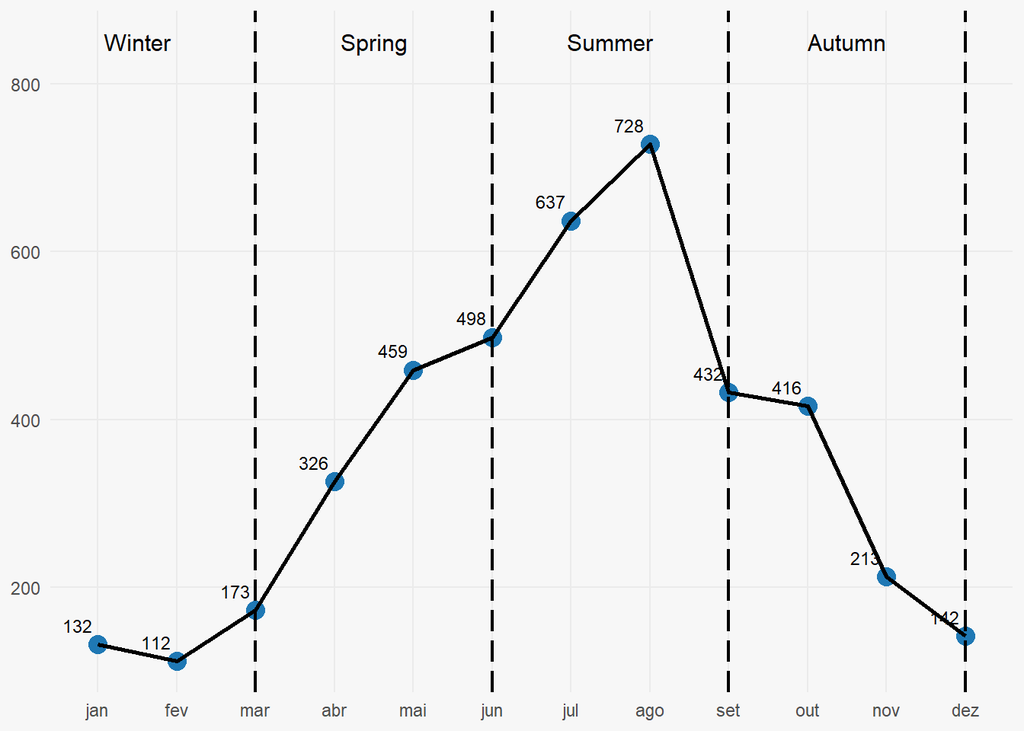

### Hires Per Month By Gender

[figure not shown]

There are more men than women who use the Citi bike service. Targeted marketing strategies and advertisements tailored to different genders could effectively increase the number of female users.

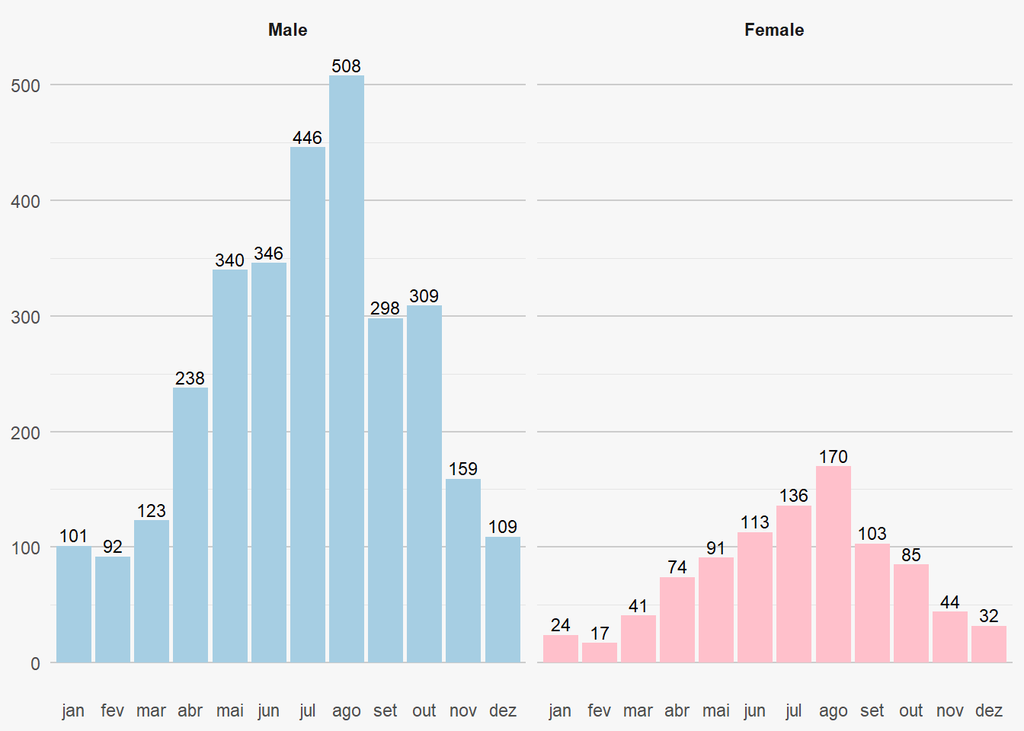

### Hires Per Weekday by Type of Customer

[figure not shown]

The workday users are likely people who commute to work. Therefore, offering customized services to make them feel more secure, such as insurance would be beneficial. Additionally, this could attract new users to the service.

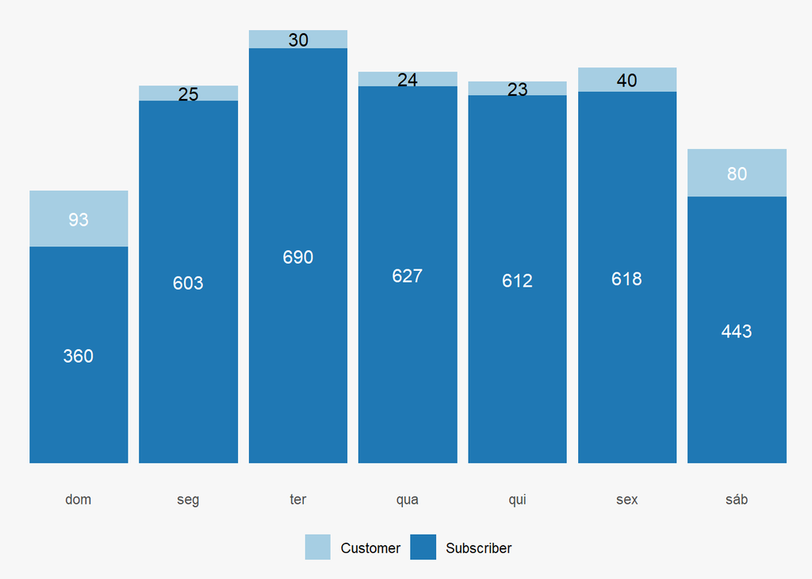

### Most Frequent Journey

[figure not shown]

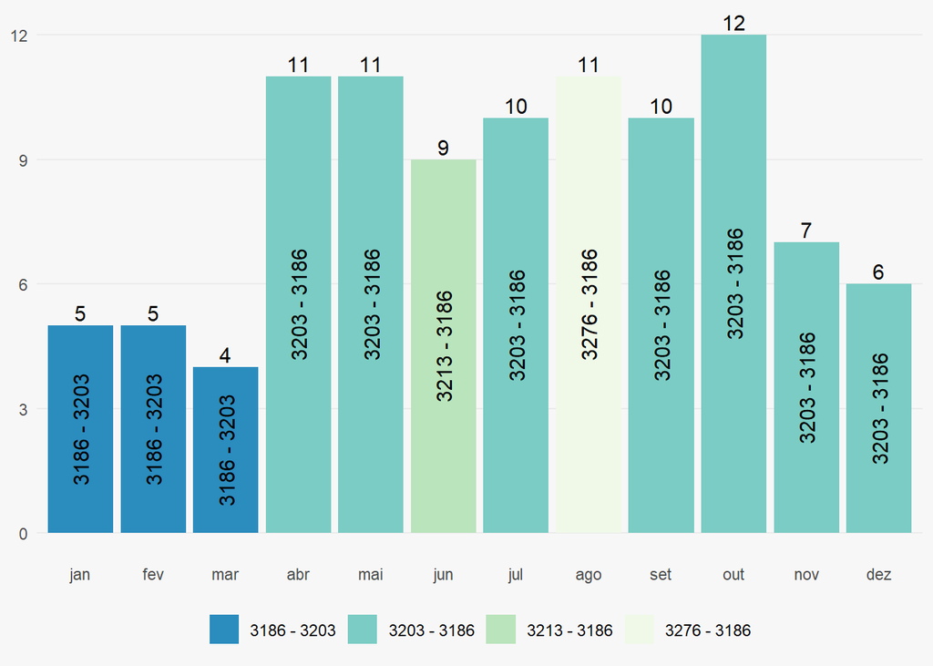

### Start Stations Locations

[figure not shown]

By hovering over each station it is possible to know which station is and the total number of hires that started there.

[interactive chart not shown]

### End Stations Locations

By hovering over each station it is possible to know which station is and the total number of hires that ended there.

[interactive chart not shown]